# Titanic Study Case Project

Sayyid Muhammad Quthb

04 April, 2021

# Problem Overview

The sinking of the Titanic is one of the most infamous shipwrecks in history. On April 15, 1912, during her maiden voyage, the widely considered “unsinkable” RMS Titanic sank after colliding with an iceberg. Unfortunately, there weren’t enough lifeboats for everyone on board, resulting in the death of 1502 out of 2224 passengers and crew. While there was some element of luck involved in surviving, it seems some groups of people were more likely to survive than others. Our objectives are to analyze and find insights about what kind of group that more likely to survive from the accident from the data given.

# Data Preparation

Before we dive into the problem, we need to understand the data. First, we need to import the data and show into a dataframe for brief knowledge about the dataset and show the data afterwards.

```r
data <- read.csv("data_input/train.csv")
data
```

| PassengerId | Survived | Pclass | Name | Sex | Age | SibSp | Parch | Ticket | Fare | Cabin | Embarked |
| --- | --- | --- | --- | --- | --- | --- | --- | --- | --- | --- | --- |
| 1 | 0 | 3 | Braund, Mr. Owen Harris | male | 22.00 | 1 | 0 | A/5 21171 | 7.2500 |  | S |
| 2 | 1 | 1 | Cumings, Mrs. John Bradley (Florence Briggs Thayer) | female | 38.00 | 1 | 0 | PC 17599 | 71.2833 | C85 | C |
| 3 | 1 | 3 | Heikkinen, Miss. Laina | female | 26.00 | 0 | 0 | STON/O2. 3101282 | 7.9250 |  | S |
| 4 | 1 | 1 | Futrelle, Mrs. Jacques Heath (Lily May Peel) | female | 35.00 | 1 | 0 | 113803 | 53.1000 | C123 | S |
| 5 | 0 | 3 | Allen, Mr. William Henry | male | 35.00 | 0 | 0 | 373450 | 8.0500 |  | S |
| 6 | 0 | 3 | Moran, Mr. James | male | NA | 0 | 0 | 330877 | 8.4583 |  | Q |
| 7 | 0 | 1 | McCarthy, Mr. Timothy J | male | 54.00 | 0 | 0 | 17463 | 51.8625 | E46 | S |
| 8 | 0 | 3 | Palsson, Master. Gosta Leonard | male | 2.00 | 3 | 1 | 349909 | 21.0750 |  | S |
| 9 | 1 | 3 | Johnson, Mrs. Oscar W (Elisabeth Vilhelmina Berg) | female | 27.00 | 0 | 2 | 347742 | 11.1333 |  | S |
| 10 | 1 | 2 | Nasser, Mrs. Nicholas (Adele Achem) | female | 14.00 | 1 | 0 | 237736 | 30.0708 |  | C |

[output cut: 881 more lines]

Table 2.1. Titanic Dataset

Additional information:  
C = Cherbourg, Q = Queenstown, S = Southampton

We want to see the data structure and its components to evaluate whether some data types need to be changed.

```r
str(data)
```

```
## 'data.frame':    891 obs. of  12 variables:
##  $ PassengerId: int  1 2 3 4 5 6 7 8 9 10 ...
##  $ Survived   : int  0 1 1 1 0 0 0 0 1 1 ...
##  $ Pclass     : int  3 1 3 1 3 3 1 3 3 2 ...
##  $ Name       : chr  "Braund, Mr. Owen Harris" "Cumings, Mrs. John Bradley (Florence Briggs Thayer)" "Heikkinen, Miss. Laina" "Futrelle, Mrs. Jacques Heath (Lily May Peel)" ...
##  $ Sex        : chr  "male" "female" "female" "female" ...
##  $ Age        : num  22 38 26 35 35 NA 54 2 27 14 ...
##  $ SibSp      : int  1 1 0 1 0 0 0 3 0 1 ...
##  $ Parch      : int  0 0 0 0 0 0 0 1 2 0 ...
##  $ Ticket     : chr  "A/5 21171" "PC 17599" "STON/O2. 3101282" "113803" ...
##  $ Fare       : num  7.25 71.28 7.92 53.1 8.05 ...
##  $ Cabin      : chr  "" "C85" "" "C123" ...
##  $ Embarked   : chr  "S" "C" "S" "S" ...
```

From the information above, some data types need to be changed:  
- Survived -> factor  
- Pclass -> factor  
- Sex -> factor  
- Embarked -> factor

```r
data$Pclass <- as.factor(data$Pclass)
data$Sex <- as.factor(data$Sex)
data$Embarked <- as.factor(data$Embarked)
data$Survived <- as.factor(data$Survived)

str(data)
```

```
## 'data.frame':    891 obs. of  12 variables:
##  $ PassengerId: int  1 2 3 4 5 6 7 8 9 10 ...
##  $ Survived   : Factor w/ 2 levels "0","1": 1 2 2 2 1 1 1 1 2 2 ...
##  $ Pclass     : Factor w/ 3 levels "1","2","3": 3 1 3 1 3 3 1 3 3 2 ...
##  $ Name       : chr  "Braund, Mr. Owen Harris" "Cumings, Mrs. John Bradley (Florence Briggs Thayer)" "Heikkinen, Miss. Laina" "Futrelle, Mrs. Jacques Heath (Lily May Peel)" ...
##  $ Sex        : Factor w/ 2 levels "female","male": 2 1 1 1 2 2 2 2 1 1 ...
##  $ Age        : num  22 38 26 35 35 NA 54 2 27 14 ...
##  $ SibSp      : int  1 1 0 1 0 0 0 3 0 1 ...
##  $ Parch      : int  0 0 0 0 0 0 0 1 2 0 ...
##  $ Ticket     : chr  "A/5 21171" "PC 17599" "STON/O2. 3101282" "113803" ...
##  $ Fare       : num  7.25 71.28 7.92 53.1 8.05 ...
##  $ Cabin      : chr  "" "C85" "" "C123" ...
##  $ Embarked   : Factor w/ 4 levels "","C","Q","S": 4 2 4 4 4 3 4 4 4 2 ...
```

Our dataset is ready to go to the further steps.

# Data Exploration

Importing libraries.

```r
library(ggplot2)
library(dplyr)
library(RColorBrewer)
```

In this step, we want to explore our data to find abnormalities and insights in our data.

```r
summary(data)
```

```
##   PassengerId    Survived Pclass      Name               Sex
##  Min.   :  1.0   0:549    1:216   Length:891         female:314
##  1st Qu.:223.5   1:342    2:184   Class :character   male  :577
##  Median :446.0            3:491   Mode  :character
##  Mean   :446.0
##  3rd Qu.:668.5
##  Max.   :891.0
##
##       Age            SibSp           Parch           Ticket
##  Min.   : 0.42   Min.   :0.000   Min.   :0.0000   Length:891
##  1st Qu.:20.12   1st Qu.:0.000   1st Qu.:0.0000   Class :character
##  Median :28.00   Median :0.000   Median :0.0000   Mode  :character
##  Mean   :29.70   Mean   :0.523   Mean   :0.3816
##  3rd Qu.:38.00   3rd Qu.:1.000   3rd Qu.:0.0000
##  Max.   :80.00   Max.   :8.000   Max.   :6.0000
##  NA's   :177
##       Fare           Cabin           Embarked
##  Min.   :  0.00   Length:891          :  2
##  1st Qu.:  7.91   Class :character   C:168
##  Median : 14.45   Mode  :character   Q: 77
##  Mean   : 32.20                      S:644
##  3rd Qu.: 31.00
##  Max.   :512.33
##
```

There are 177 missing values in “Age” column, we can do NA imputation to fill the missing values. Moreover, “Name” and “Cabin” is considered to be unique values. In predicting whether a passanger survived or not, we don’t need unique values. Thus, we can drop the columns. There are also 2 missing values in “Embarked” column.

## Solving Missing Values in Embarked Column

Firstly, We want to know the information about those 2 passengers whose the embarked status is unknown.

```r
as.data.frame(data[data$Embarked == "", ])
```

|  | PassengerId | Survived | Pclass | Name | Sex | Age | SibSp | Parch | Ticket | Fare | Cabin | Embarked |
| --- | --- | --- | --- | --- | --- | --- | --- | --- | --- | --- | --- | --- |
| 62 | 62 | 1 | 1 | Icard, Miss. Amelie | female | 38 | 0 | 0 | 113572 | 80 | B28 |  |
| 830 | 830 | 1 | 1 | Stone, Mrs. George Nelson (Martha Evelyn) | female | 62 | 0 | 0 | 113572 | 80 | B28 |  |

Table 3.1.1. Passengers with Unknown Embarked Status

There are 2 passengers with the information as shown below:  
1. Ms. Amelie Icard:  
- PassengerId = 62  
- Sex = Female  
- Age = 38  
- Pclass = 1  
- SibSp = 0  
- Parch = 0  
- Fare = 80  
- Survived = yes  
2. Mrs. George Nelson Stone:  
- PassengerId = 830  
- Sex = Female  
- Age = 62  
- Pclass = 1  
- SibSp = 0  
- Parch = 0  
- Fare = 80  
- Survived = yes

```r
aggregate(Fare ~ Pclass + Embarked, data = data, FUN = "median")
```

| Pclass | Embarked | Fare |
| --- | --- | --- |
| 1 |  | 80.0000 |
| 1 | C | 78.2667 |
| 2 | C | 24.0000 |
| 3 | C | 7.8958 |
| 1 | Q | 90.0000 |
| 2 | Q | 12.3500 |
| 3 | Q | 7.7500 |
| 1 | S | 52.0000 |
| 2 | S | 13.5000 |
| 3 | S | 8.0500 |

Table 3.1.2. Aggregate Table of Passenger Class and Embarked Status Based on Fare Price

Both passengers have the same information in some columns. Hence, we can find the embarked status according some condition which are:  
- Passenger Class = 1 (Because they were from 1st class)  
- Fare = 78 < x < 90 (Because their fare price was 80)  
- PassengerId > 60 (Because both passengers Id was above 60)  
- SibSP and Parch = 0 (Because nethier of them went with their sibling/ spouse/ parent/ child)

```r
summary(as.data.frame(data[data$Pclass == 1 & data$Fare > 78 & data$Fare < 90 & data$PassengerId > 60 & data$Parch == 0 & data$SibSp == 0, ]))
```

```
##   PassengerId    Survived Pclass     Name               Sex         Age
##  Min.   : 62.0   0:2      1:10   Length:10          female:8   Min.   :16.00
##  1st Qu.:257.2   1:8      2: 0   Class :character   male  :2   1st Qu.:24.00
##  Median :301.0            3: 0   Mode  :character              Median :30.00
##  Mean   :420.4                                                 Mean   :33.22
##  3rd Qu.:696.2                                                 3rd Qu.:38.00
##  Max.   :830.0                                                 Max.   :62.00
##                                                                NA's   :1
##      SibSp       Parch      Ticket               Fare          Cabin
##  Min.   :0   Min.   :0   Length:10          Min.   :78.85   Length:10
##  1st Qu.:0   1st Qu.:0   Class :character   1st Qu.:79.20   Class :character
##  Median :0   Median :0   Mode  :character   Median :80.00   Mode  :character
##  Mean   :0   Mean   :0                      Mean   :81.91
##  3rd Qu.:0   3rd Qu.:0                      3rd Qu.:85.66
##  Max.   :0   Max.   :0                      Max.   :86.50
##
##  Embarked
##   :2
##  C:4
##  Q:0
##  S:4
##
##
##
```

We got 2 options which are “C” and “S”. We will choose “C” because the median fare for “C” is close to 80.

```r
data[data$Embarked == "", "Embarked"] <- "C"
```

## Solving Missing Values in Age Column

In our data, the “Age” is vary and there are 3 passenger classes that may have different median of “Age”. So, we will make a boxplot to find the median for each class.

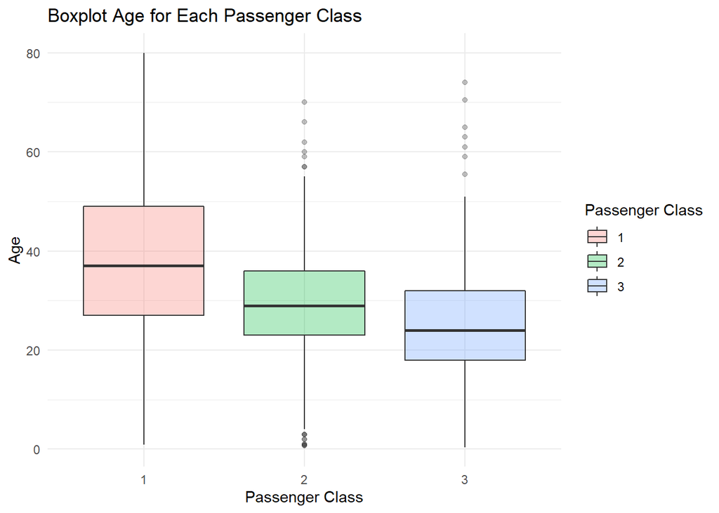

```r
ggplot(data, aes(x = Pclass, y = Age, fill = Pclass)) +
  geom_boxplot(na.rm = TRUE, alpha = 0.3) +
  labs(title = "Boxplot Age for Each Passenger Class",
       x = "Passenger Class",
       y = "Age",
       fill = "Passenger Class") +
  theme(plot.title = element_text(hjust = 0.5, size = 14),
        legend.position = "none") +
  theme_minimal()
```

There are 3 different median of “Age” for each class. But, We want to have updated value for each median. In order to cope this, we can subset the median “Age” for each class.

```r
medianclass1 <- data[data$Pclass == 1, c("Age", "Pclass")]
medianclass2 <- data[data$Pclass == 2, c("Age", "Pclass")]
medianclass3 <- data[data$Pclass == 3, c("Age", "Pclass")]

median1 <- median(medianclass1$Age, na.rm = TRUE)
median2 <- median(medianclass2$Age, na.rm = TRUE)
median3 <- median(medianclass3$Age, na.rm = TRUE)
```

```r
impute_age <- function(age, pclass){
  # age <- data$Age
  # pclass <- data$Pclass

  if (is.na(age)){
    if (pclass == 1){
      return (median1)
    }
    else if (pclass == 2){
      return (median2)
    }
    else {
      return (median3)
    }
  }
  else {
    return (age)
  }
}
```

```r
data$Age <- mapply(FUN = impute_age, age = data$Age, pclass = data$Pclass)

summary(data)
```

```
##   PassengerId    Survived Pclass      Name               Sex
##  Min.   :  1.0   0:549    1:216   Length:891         female:314
##  1st Qu.:223.5   1:342    2:184   Class :character   male  :577
##  Median :446.0            3:491   Mode  :character
##  Mean   :446.0
##  3rd Qu.:668.5
##  Max.   :891.0
##       Age            SibSp           Parch           Ticket
##  Min.   : 0.42   Min.   :0.000   Min.   :0.0000   Length:891
##  1st Qu.:22.00   1st Qu.:0.000   1st Qu.:0.0000   Class :character
##  Median :26.00   Median :0.000   Median :0.0000   Mode  :character
##  Mean   :29.07   Mean   :0.523   Mean   :0.3816
##  3rd Qu.:37.00   3rd Qu.:1.000   3rd Qu.:0.0000
##  Max.   :80.00   Max.   :8.000   Max.   :6.0000
##       Fare           Cabin           Embarked
##  Min.   :  0.00   Length:891          :  0
##  1st Qu.:  7.91   Class :character   C:170
##  Median : 14.45   Mode  :character   Q: 77
##  Mean   : 32.20                      S:644
##  3rd Qu.: 31.00
##  Max.   :512.33
```

# Data VIsualization

correlation between gender, pclass, and survived

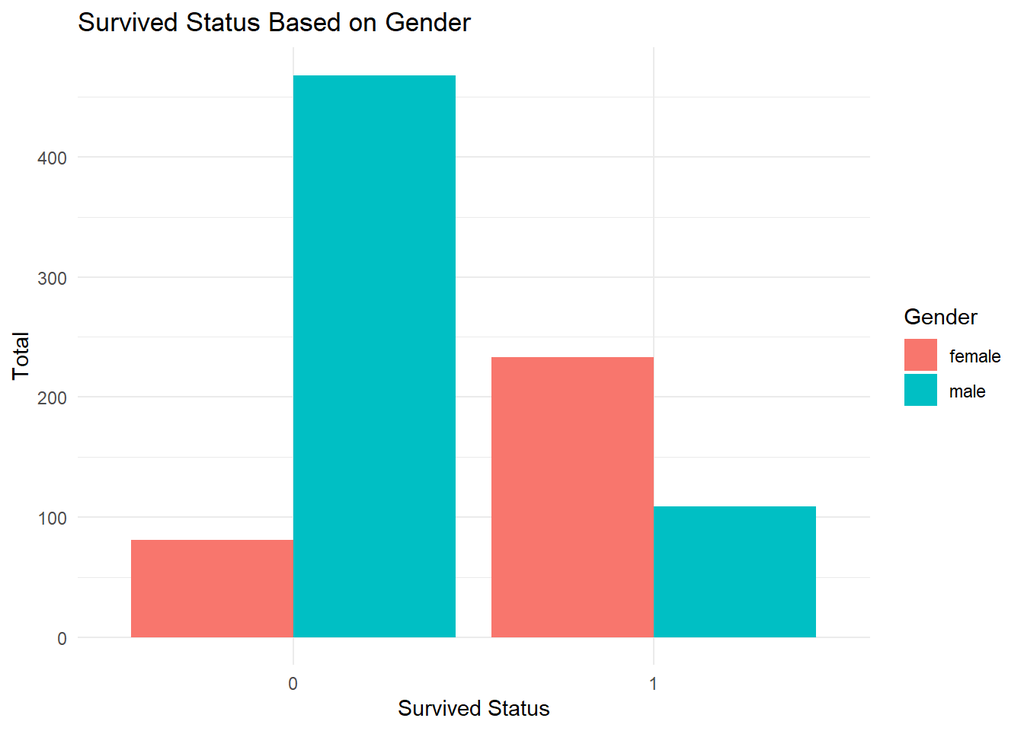

```r
ggplot(data = data, aes(x = Survived, fill = Sex)) +
  geom_bar(position = "dodge") +
  labs(title = "Survived Status Based on Gender",
       x = "Survived Status",
       y = "Total",
       fill = "Gender") +
  theme_minimal()
```

FIgure 4.1. Survived Status for Each Gender

From the chart above, we know that the majority of people who survived were female. majority of male did not survive.

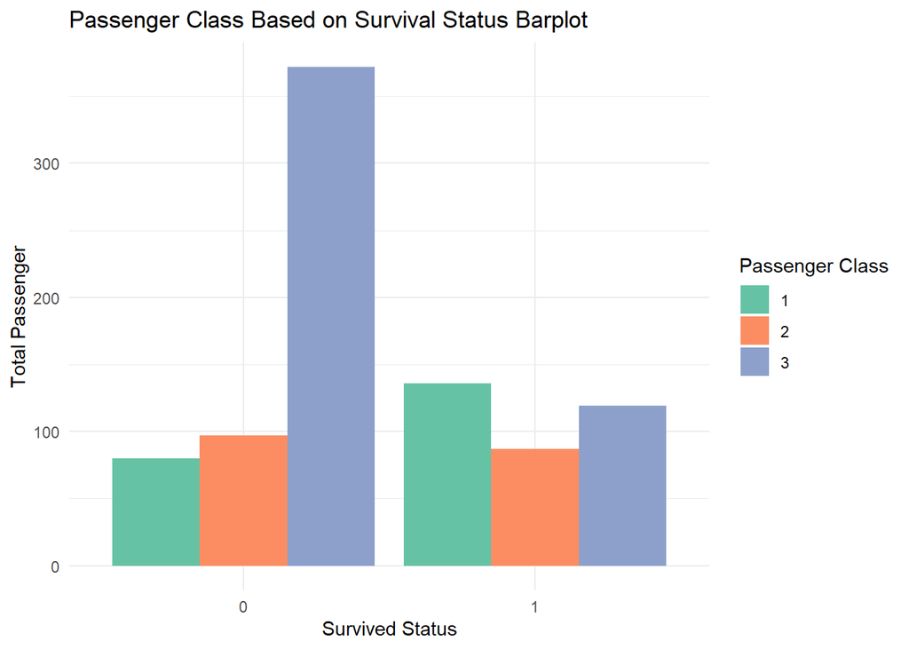

```r
ggplot(data = data, aes(x = Survived, fill = Pclass)) +
  geom_bar(position = "dodge") +
  labs(title = "Passenger Class Based on Survival Status Barplot",
       x = "Survived Status",
       y = "Total Passenger",
       fill = "Passenger Class") +
  scale_fill_brewer(palette = "Set2") +
  theme(legend.position="top") +
  theme_minimal()
```

FIgure 4.2. Survived Status for Each Class

We got a new insight about the data distribution, people who from 3rd class are more likely to not survive, where the 2nd class is distributed evenly, and 1st class are more likely to survive from the accident.

Aggregating male passengers based on passenger class.

```r
male <- data[data$Sex == "male", ]
aggregate(Sex ~ Pclass + Survived, data = male, FUN = "length")
```

| Pclass | Survived | Sex |
| --- | --- | --- |
| 1 | 0 | 77 |
| 2 | 0 | 91 |
| 3 | 0 | 300 |
| 1 | 1 | 45 |
| 2 | 1 | 17 |
| 3 | 1 | 47 |

Table 4.1. Passengers Survived Male Only

```r
female <- data[data$Sex == "female", ]
aggregate(Sex ~ Pclass + Survived, data = male, FUN = "length")
```

| Pclass | Survived | Sex |
| --- | --- | --- |
| 1 | 0 | 77 |
| 2 | 0 | 91 |
| 3 | 0 | 300 |
| 1 | 1 | 45 |
| 2 | 1 | 17 |
| 3 | 1 | 47 |

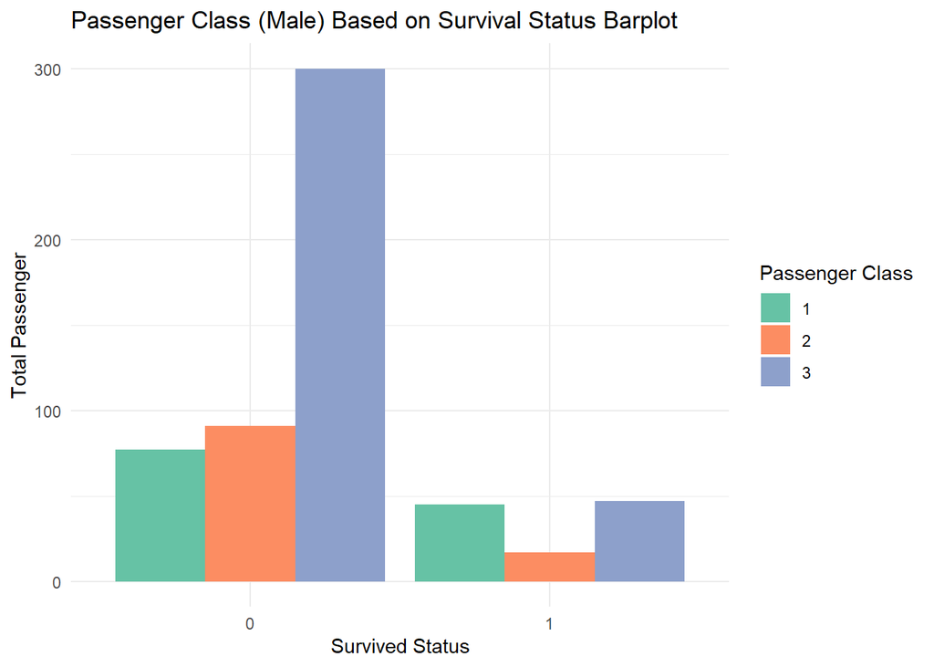

```r
ggplot(data = male, aes(x = Survived, fill = Pclass)) +
  geom_bar(position = "dodge") +
  labs(title = "Passenger Class (Male) Based on Survival Status Barplot",
       x = "Survived Status",
       y = "Total Passenger",
       fill = "Passenger Class") +
  scale_fill_brewer(palette = "Set2") +
  theme(legend.position="top") +
  theme_minimal()
```

FIgure 4.3. Distribution of Male Passengers Survived for Each Class

Male Passengers from 3rd class are less likely to survive rather than the other classes.

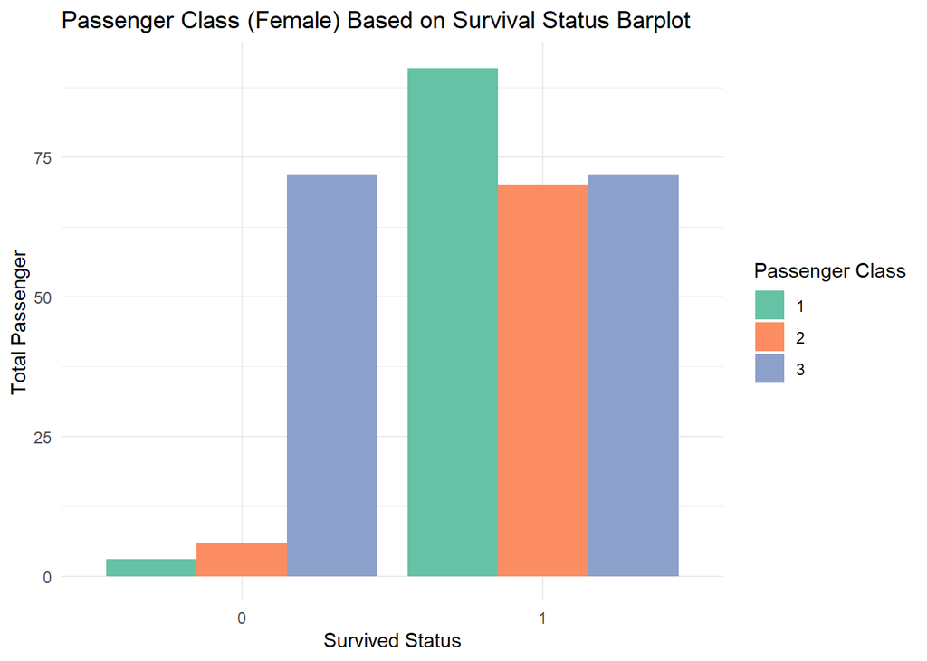

```r
ggplot(data = female, aes(x = Survived, fill = Pclass)) +
  geom_bar(position = "dodge") +
  labs(title = "Passenger Class (Female) Based on Survival Status Barplot",
       x = "Survived Status",
       y = "Total Passenger",
       fill = "Passenger Class") +
  scale_fill_brewer(palette = "Set2") +
  theme(legend.position="top") +
  theme_minimal()
```

FIgure 4.4. Distribution of Female Passengers Survived for Each Class

Female passengers from 3rd class are less likely to survive rather than the other classes.

```r
data_subset <- data[, c("Survived", "Pclass", "Sex")]

data_agg <- data_subset %>%
  mutate(Survived = as.factor(Survived)) %>%
  count(Sex, Survived, Pclass, sort = TRUE)

data_agg
```

| Sex | Survived | Pclass | n |
| --- | --- | --- | --- |
| male | 0 | 3 | 300 |
| female | 1 | 1 | 91 |
| male | 0 | 2 | 91 |
| male | 0 | 1 | 77 |
| female | 0 | 3 | 72 |
| female | 1 | 3 | 72 |
| female | 1 | 2 | 70 |
| male | 1 | 3 | 47 |
| male | 1 | 1 | 45 |
| male | 1 | 2 | 17 |

[output cut: 2 more lines]

Table 4.3. Number of Passenger Survived Based on Gender and Passenger Class

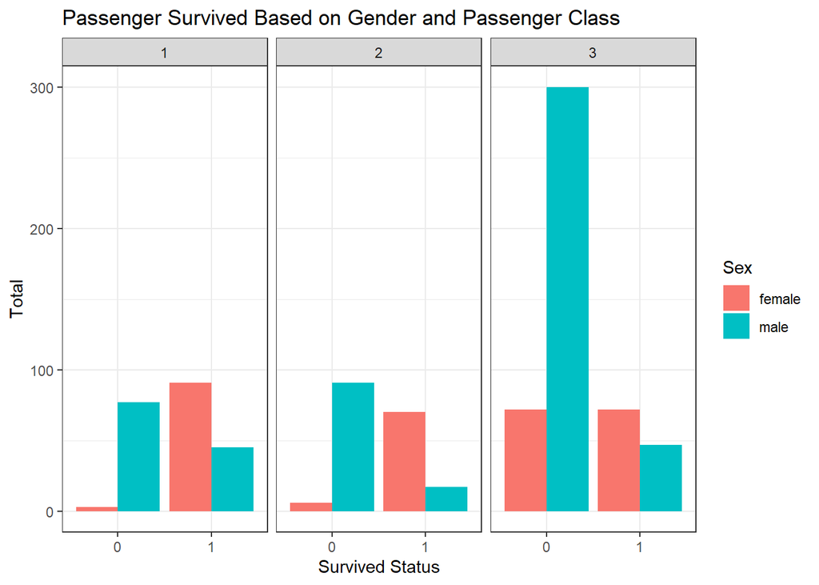

```r
ggplot(data_agg, mapping = aes(x = Survived, y = n)) +
  geom_col(aes(fill = Sex), position = "dodge") +
  labs(title = "Passenger Survived Based on Gender and Passenger Class",
       x = "Survived Status",
       y = "Total") +
  facet_wrap(~Pclass) +
  theme_bw()
```

Figure 4.5. Barchart of People Survived Based on Gender and Passenger Class

We want to see the distribution of sruvived status based on their ages.

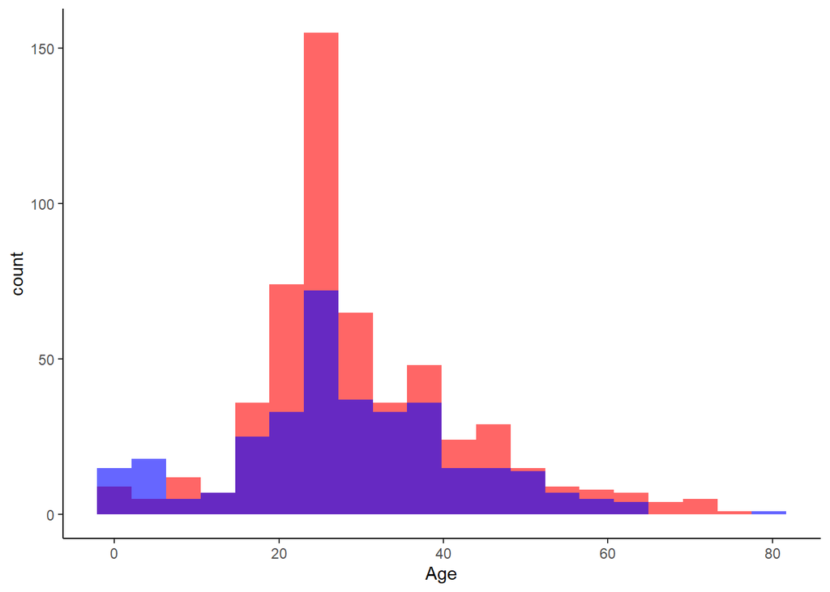

```r
ggplot(data, aes(x = Age)) +
  geom_histogram(data = data[data$Survived == 0, ], fill = "red", alpha=0.6, position="identity", bins = 20) +
  geom_histogram(data = data[data$Survived == 1, ], fill = "blue", alpha=0.6, position="identity", bins = 20) +
  theme_classic()
```

Figure 4.6. Histogram of People Survived Based on Age (Survived = blue, Not Survived = red)

Most of passengers older than 60 years old didn’t survive at the accident. Meanwhile, most of passengers younger than 10 years old survived at the accident.

In some conditions, people from the same area tend to have same characters which might affect their reactions when an accident happened. So, we will try to find correlation between embarked status and survived status.

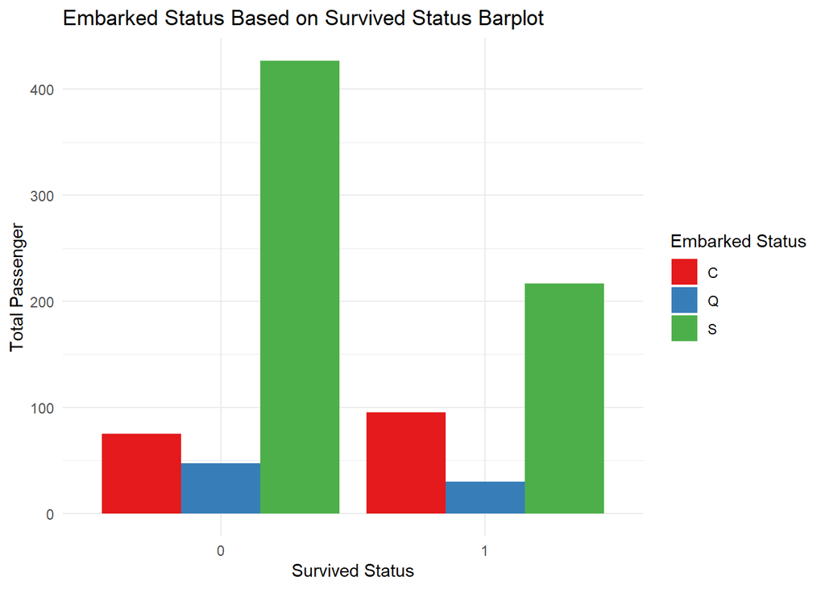

```r
ggplot(data = data, aes(x = Survived, fill = Embarked)) +
  geom_bar(position = "dodge") +
  labs(title = "Embarked Status Based on Survived Status Barplot",
       x = "Survived Status",
       y = "Total Passenger",
       fill = "Embarked Status") +
  scale_fill_brewer(palette = "Set1") +
  theme(legend.position="top") +
  theme_minimal()
```

Figure 4.7. Barplot of People Survived Based on Embarked Status

```r
data_subset2 <- data[, c("Survived", "Embarked", "Sex")]

data_agg2 <- data_subset2 %>%
  mutate(Survived = as.factor(Survived)) %>%
  count(Sex, Survived, Embarked, sort = TRUE)

data_agg2
```

| Sex | Survived | Embarked | n |
| --- | --- | --- | --- |
| male | 0 | S | 364 |
| female | 1 | S | 140 |
| male | 1 | S | 77 |
| female | 1 | C | 66 |
| male | 0 | C | 66 |
| female | 0 | S | 63 |
| male | 0 | Q | 38 |
| male | 1 | C | 29 |
| female | 1 | Q | 27 |
| female | 0 | C | 9 |

[output cut: 2 more lines]

Table 4.4. Table of People Survived Based on Gender and Embarked Status

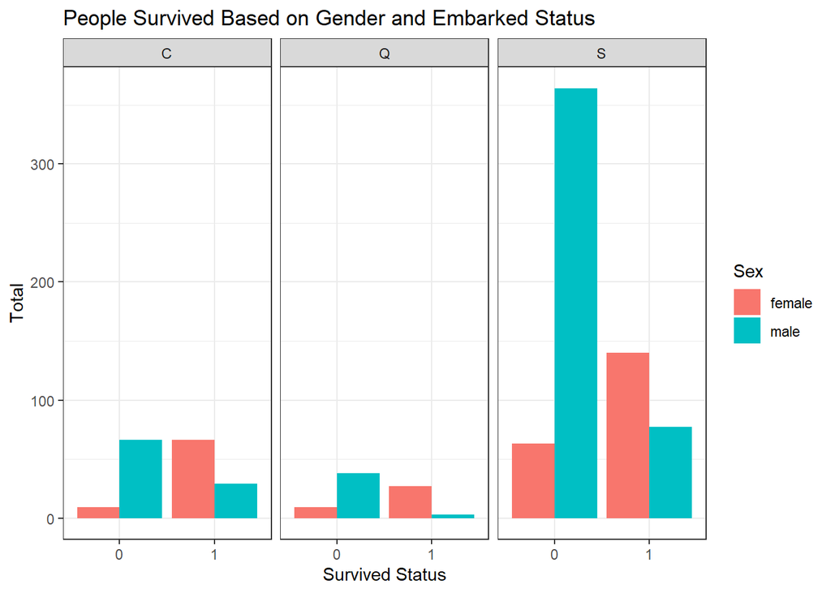

```r
ggplot(data_agg2, mapping = aes(x = Survived, y = n)) +
  geom_col(aes(fill = Sex), position = "dodge") +
  labs(title = "People Survived Based on Gender and Embarked Status",
       x = "Survived Status",
       y = "Total") +
  facet_wrap(~Embarked) +
  theme_bw()
```

Figure 4.8. Barplot of People Survived Based on Gender and Embarked Status

As it shown above, most casualties are from male passengers who boarded from Southampton (S). THe number of female who boarded from Southampton (S) and didn’t survive almost the same as female passengers who boarded from Cherbourg (C) and survived from the accident.

```r
data_subset3 <- data[, c("Survived", "Embarked", "Pclass")]

data_agg3 <- data_subset3 %>%
  mutate(Survived = as.factor(Survived)) %>%
  count(Pclass, Survived, Embarked, sort = TRUE)

data_agg3
```

| Pclass | Survived | Embarked | n |
| --- | --- | --- | --- |
| 3 | 0 | S | 286 |
| 2 | 0 | S | 88 |
| 2 | 1 | S | 76 |
| 1 | 1 | S | 74 |
| 3 | 1 | S | 67 |
| 1 | 1 | C | 61 |
| 1 | 0 | S | 53 |
| 3 | 0 | Q | 45 |
| 3 | 0 | C | 41 |
| 3 | 1 | Q | 27 |

[output cut: 8 more lines]

Table 4.5. Table of People Survived Based on Passenger Class and Embarked Status

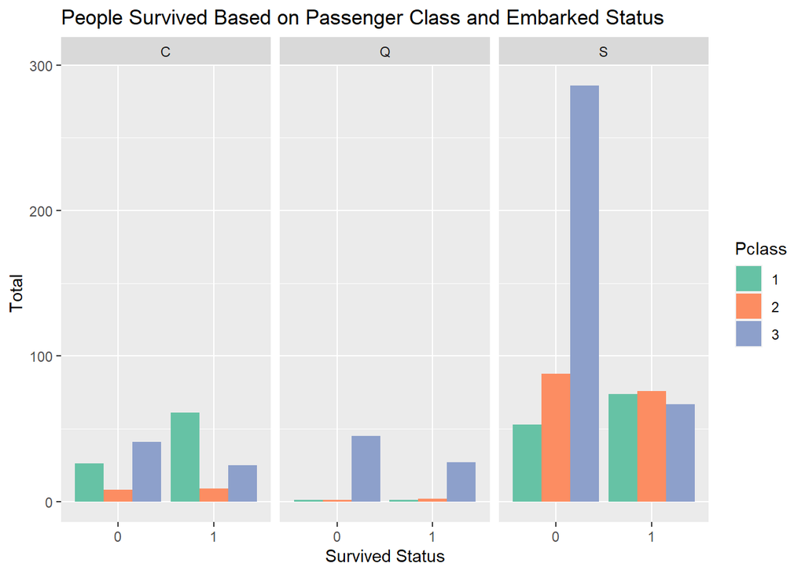

```r
ggplot(data_agg3, mapping = aes(x = Survived, y = n)) +
  geom_col(aes(fill = Pclass), position = "dodge") +
  labs(title = "People Survived Based on Passenger Class and Embarked Status",
       x = "Survived Status",
       y = "Total") +
  scale_fill_brewer(palette = "Set2") +
  facet_wrap(~Embarked)
```

Figure 4.9. Barplot of People Survived Based on Passenger Class and Embarked Status